# Clathrate Framework Bond Length Analysis

Don Ngo, Julia Maria Hubner, Anirudh Prabhu

2026-10-29

## Interactive manuscript figures

Figure 2

Hover over points to inspect the contributing records. Use the Plotly controls to zoom or reset the view.

## 1. Objective and Methodology

This report documents the final, robust workflow for analyzing a curated dataset of categorized Clathrate I CIF files. The goal is to calculate the weighted average network bond distance for each structure and explore its relationship with the lattice parameter ‘a’. The methodology incorporates a multi-step filtering pipeline to handle the complexities of real-world crystallographic data, such as site-occupancy disorder and non-physical “ghost” distances.

### 1.1. Loading Categorized CIF Files

The curated dataset is organized into subdirectories defining the specific filtering rules for the files within (e.g., `6c-16i-24k`). The script recursively finds all CIF files and maps each one to its structural category.

```r
cif_root_dir <- normalizePath(params$cif_root_dir, mustWork = TRUE)

if (!dir.exists(cif_root_dir)) stop(paste("CRITICAL ERROR: Root directory not found:", cif_root_dir))

category_dirs <- list.dirs(path = cif_root_dir, full.names = TRUE, recursive = FALSE)

file_map_list <- lapply(category_dirs, function(dir) {
  full_paths <- list.files(path = dir, pattern = "\\.cif$", full.names = TRUE, ignore.case = TRUE)
  if (length(full_paths) == 0) return(NULL)
  data.table(file_path = full_paths, file_name = basename(full_paths), category = basename(dir))
})

file_map <- rbindlist(file_map_list, fill = TRUE)
all_cif_paths <- if (nrow(file_map) > 0) file_map$file_path else character(0)

cat("Found", length(all_cif_paths), "total CIF files across", length(category_dirs), "categories.\n")
```

```
## Found 705 total CIF files across 10 categories.
```

```r
if (length(all_cif_paths) == 0) stop("Execution stopped: No CIF files were found.")
```

## 2. Optimized Batch Analysis of Crystal Structures

We use the main `analyze_cif_files()` function with optimized parameters to extract raw data and calculate all interatomic distances. Subsequent bonding algorithms and non-essential calculations are disabled to improve performance, as these will be handled by our custom pipeline.

```r
analysis_results <- analyze_cif_files(
  file_paths = all_cif_paths,
  perform_extraction = TRUE,
  perform_calcs_and_transforms = TRUE,
  bonding_algorithms = "none", # Disable default bonding to use our custom method
  calculate_bond_angles = FALSE,
  perform_error_propagation = FALSE
)
cat("Optimized analysis complete. Raw results table has", nrow(analysis_results), "rows.\n")
```

```
## Optimized analysis complete. Raw results table has 705 rows.
```

## 3. Data Processing and Calculation Pipeline

This section implements the core filtering and calculation logic. The robust workflow (Guests -> Ghosts -> Bonds -> Average) is applied to each file to ensure accurate and reliable results.

```r
# --- Timing Start ---
timing_processing <- system.time({
  guest_atoms <- c("Na", "K", "Rb", "Cs", "Sr", "Ba", "Eu")
  all_removed_ghosts <- list()

  process_file_results <- function(i) {
    current_filename <- analysis_results$file_name[i]
    category_info <- file_map[file_name == current_filename]
    if (nrow(category_info) > 1L) stop("Duplicate CIF basenames in the input categories")
    if (is.null(current_filename) ||
        nrow(category_info) == 0)
      return(NULL)

    distances <- analysis_results$distances[[i]]
    coords <- analysis_results$atomic_coordinates[[i]]
    if (is.null(distances) ||
        is.null(coords) || nrow(distances) == 0)
      return(NULL)

    # --- Step 1: Parse Category Rules and Filter Guests ---
    category <- category_info$category
    target_wyckoff_symbols <- strsplit(sub("[+-]M_on_.*", "", category), "-")[[1]]

    # Unconditionally filter out guest atoms to analyze the host framework
    distances <- filter_by_elements(distances, coords, guest_atoms)

    if (nrow(distances) == 0)
      return(NULL)

    # --- Step 2: Filter "Ghost" Distances (Covalent Radii Method) ---
    ghost_filter_result <- filter_ghost_distances(distances, coords, margin = 0.1)
    cleaned_distances <- ghost_filter_result$kept

    # Store removed distances for quality control
    removed_table <- ghost_filter_result$removed
    if (nrow(removed_table) > 0) {
      removed_table[, file := current_filename]
      all_removed_ghosts[[length(all_removed_ghosts) + 1]] <<- removed_table
    }
    if (nrow(cleaned_distances) == 0)
      return(NULL)

    # --- Step 3: Identify Bonded Pairs (Minimum Distance Method) ---
    bonded_pairs <- minimum_distance(cleaned_distances, delta = 0.1)
    if (nrow(bonded_pairs) == 0)
      return(NULL)

    # --- Step 4: Calculate Final Weighted Average ---
    weighted_avg <- calculate_weighted_average_network_distance(bonded_pairs, coords, target_wyckoff_symbols)
    if (is.na(weighted_avg))
      return(NULL)

    return(
      data.table(
        file = current_filename,
        category = category,
        chemical_formula = analysis_results$chemical_formula[i],
        lattice_parameter_a = analysis_results$unit_cell_metrics[[i]]$`_cell_length_a`,
        weighted_distance = weighted_avg
      )
    )
  }

  # Execute the processing for all files
  plot_data_list <- lapply(1:nrow(analysis_results), process_file_results)
  plot_data <- rbindlist(plot_data_list, use.names = TRUE, fill = TRUE)
  plot_data <- na.omit(plot_data)
  plot_data[, composition_key := composition_key(chemical_formula)]
  removed_ghosts_summary <- rbindlist(all_removed_ghosts, fill = TRUE)
}) # --- Timing End ---

# Final summary output
cat("Data processing complete. Final plot table has",
    nrow(plot_data),
    "entries.\n")
```

```
## Data processing complete. Final plot table has 705 entries.
```

```r
if (exists("removed_ghosts_summary") &&
    nrow(removed_ghosts_summary) > 0) {
  cat(
    nrow(removed_ghosts_summary),
    "non-physical 'ghost' distances were identified and removed across all files.\n"
  )
}
```

```
## 5292580 non-physical 'ghost' distances were identified and removed across all files.
```

## 4. Quality Control: Review of Removed “Ghost” Distances

This section summarizes the interatomic distances that were automatically filtered out as non-physical *before* bond identification. A sample of up to 1,000 such distances is shown below, and the complete list is saved to a separate CSV file for full analysis.

```r
export_dir <- params$export_dir
dir.create(export_dir, recursive = TRUE, showWarnings = FALSE)

if (exists("removed_ghosts_summary") && nrow(removed_ghosts_summary) > 0) {
  full_csv_path <- file.path(export_dir, "removed_ghosts_summary.csv")
  fwrite(removed_ghosts_summary, full_csv_path)
  cat(paste("Full list of", nrow(removed_ghosts_summary), "removed distances saved to:", full_csv_path, "\n\n"))

  sample_size <- min(1000, nrow(removed_ghosts_summary))
  cat(paste("Displaying a sample of the first", sample_size, "removed distances below:\n"))

  datatable(
    removed_ghosts_summary[1:sample_size, ],
    caption = paste("Sample of Removed Ghost Distances (", sample_size, " of ", nrow(removed_ghosts_summary), " total)"),
    rownames = FALSE, extensions = 'Buttons',
    options = list(pageLength = 10, dom = 'Bfrtip', buttons = c('copy', 'csv')),
    colnames = names(removed_ghosts_summary)
  )
} else {
  cat("No 'ghost' distances were detected during the analysis.")
}
```

```
## Full list of 5292580 removed distances saved to: interactive_report_files/removed_ghosts_summary.csv
##
## Displaying a sample of the first 1000 removed distances below:
```

| Atom1 | Atom2 | Distance | expected_dist | lower_bound | upper_bound | Reason | file |
| --- | --- | --- | --- | --- | --- | --- | --- |
| As1 | As1_1_-1_-1_-1 | 12.68249456444998 | 2.42 | 2.178 | 2.662 | Distance is TOO LONG | ClathrateI_all_CollCode423637.cif |
| As1 | As1_4_-1_-1_-1 | 15.05382097690173 | 2.42 | 2.178 | 2.662 | Distance is TOO LONG | ClathrateI_all_CollCode423637.cif |
| As1 | As1_7_-1_-1_-1 | 12.68249456444998 | 2.42 | 2.178 | 2.662 | Distance is TOO LONG | ClathrateI_all_CollCode423637.cif |
| As1 | As1_10_-1_-1_-1 | 15.05382097690173 | 2.42 | 2.178 | 2.662 | Distance is TOO LONG | ClathrateI_all_CollCode423637.cif |
| As1 | As1_13_-1_-1_-1 | 12.68249456444998 | 2.42 | 2.178 | 2.662 | Distance is TOO LONG | ClathrateI_all_CollCode423637.cif |
| As1 | As1_16_-1_-1_-1 | 15.05382097690173 | 2.42 | 2.178 | 2.662 | Distance is TOO LONG | ClathrateI_all_CollCode423637.cif |
| As1 | As1_19_-1_-1_-1 | 17.09939717159379 | 2.42 | 2.178 | 2.662 | Distance is TOO LONG | ClathrateI_all_CollCode423637.cif |
| As1 | As1_22_-1_-1_-1 | 9.750580021208993 | 2.42 | 2.178 | 2.662 | Distance is TOO LONG | ClathrateI_all_CollCode423637.cif |
| As1 | As1_25_-1_-1_-1 | 16.47822400937866 | 2.42 | 2.178 | 2.662 | Distance is TOO LONG | ClathrateI_all_CollCode423637.cif |
| As1 | As1_28_-1_-1_-1 | 12.75807548208297 | 2.42 | 2.178 | 2.662 | Distance is TOO LONG | ClathrateI_all_CollCode423637.cif |

[output cut: 990 more lines]

## 5. Final Results

The plot below visualizes the final, cleaned data, showing the relationship between the calculated weighted average network bond length and the lattice parameter ‘a’.

```r
p <- ggplot(plot_data, aes(x = lattice_parameter_a, y = weighted_distance, color = category, shape = category, text = file)) +
  geom_point(alpha = 0.65, size = 2.5) +
  scale_shape_manual(values = c(16, 17, 15, 3, 4, 8, 0, 1, 2, 5)) +
  geom_smooth(aes(group = 1), method = "lm", se = FALSE, color = "black", linetype = "dotted", fullrange = TRUE) +
  annotate("segment", x=10.65, y=2.525, xend=12.16, yend=2.893,
           linetype="dashed", linewidth=0.65, color="black") +
  annotate("text", x=10.85, y=2.84, label="Inverse\nclathrates", size=3.3) +
  annotate("segment", x=11.05, y=2.79, xend=11.34, yend=2.735,
           arrow=grid::arrow(length=grid::unit(0.10,"inches")), linewidth=0.4) +
  labs(
    title = "Average Network Bond Length vs. Lattice Parameter 'a'",
    subtitle = sprintf("%d CIF records; %d distinct compositions",
                       nrow(plot_data), uniqueN(plot_data$composition_key, na.rm = TRUE)),
    x = "Lattice Parameter a (Å)",
    y = "Weighted Average Network Bond Length (Å)",
    color = "Structural Category", shape = "Structural Category"
  ) +
  theme_bw(base_size = 14) +
  theme(legend.position = "bottom", legend.title = element_text(face = "bold"))

stopifnot(!anyNA(ggplot_build(p)$data[[1]]$shape))
interactive_plot <- ggplotly(p, tooltip = c("x", "y", "text", "color"))
interactive_plot
```

[interactive chart not shown]

The dotted line is the overall least-squares fit. The dashed line and inverse-clathrate annotation are an approximate digitization of the original figure’s visual guide, not a regression on an independently classified subset. The original subset labels and line equation are unavailable; the guide alone does not establish a separate slope or chemical mechanism. Its endpoints are exported for reproducibility.

```r
fwrite(data.table(x=c(10.65,12.16), y=c(2.525,2.893),
                 definition="Approximate visual-guide endpoints digitized from original figure; not a subset regression"),
       file.path(export_dir,"inverse_clathrate_visual_guide.csv"))
```

### 5.1. Interactive Data Table

This table contains the final data used in the plot above. It can be searched, sorted, and exported.

```r
datatable(
  plot_data,
  caption = "Final Processed Data for Clathrate Structures",
  rownames = FALSE, filter = 'top', extensions = 'Buttons',
  options = list(pageLength = 15, dom = 'Bfrtip', buttons = c('copy', 'csv', 'excel')),
  colnames = c("File", "Category", "Reported formula", "Lattice 'a' (Å)", "Weighted Dist (Å)", "Composition key")
)
```

| File | Category | Reported formula | Lattice 'a' (Å) | Weighted Dist (Å) | Composition key |
| --- | --- | --- | --- | --- | --- |
| ClathrateI_all_CollCode423637.cif | 12g-16i-24k | As21.6 I8 In6.9 Sn15.8 | 11.259 | 2.601105910997379 | As 0.413002;I 0.152964;In 0.131931;Sn 0.302103 |
| ClathrateI_all_CollCode423638.cif | 12g-16i-24k | As21.8 I8 In5 Sn17.1 | 11.197 | 2.572188285909551 | As 0.420039;I 0.154143;In 0.096339;Sn 0.329480 |
| ClathrateI_all_CollCode416531.cif | 24k-48l | As22 I8 Sn20.6 | 11.088 | 2.550022030003778 | As 0.434783;I 0.158103;Sn 0.407115 |
| ClathrateI_all_CollCode423639.cif | 24k-48l | As22 I8 In4.8 Sn17 | 11.1819 | 2.562407354615038 | As 0.424710;I 0.154440;In 0.092664;Sn 0.328185 |
| ClathrateI_all_CollCode423640.cif | 24k-48l | As22 I8 In4.1 Sn17.5 | 11.168 | 2.565496150593316 | As 0.426357;I 0.155039;In 0.079457;Sn 0.339147 |
| Ba8Ni6Ge40-217808.cif | 6c-16i-24k | Ba8 Ge40 Ni6 | 10.6754 | 2.48533830031868 | Ba 0.148148;Ge 0.740741;Ni 0.111111 |
| Ca-B-C-clatI-2338100-corr.cif | 6c-16i-24k | C37.12 B8.88 Ca8 | 7.0464 | 1.63318267087738 | B 0.164444;C 0.687407;Ca 0.148148 |
| ClathrateI_all_CollCode100103.cif | 6c-16i-24k | Ga23 Ge23 K8 | 10.762 | 2.498383199478758 | Ga 0.425926;Ge 0.425926;K 0.148148 |
| ClathrateI_all_CollCode120108.cif | 6c-16i-24k | Ba8 Ga6 Si40 | 10.4261 | 2.393389710560864 | Ba 0.148148;Ga 0.111111;Si 0.740741 |
| ClathrateI_all_CollCode120109.cif | 6c-16i-24k | Ba8 Ga10 Si36 | 10.4896 | 2.434927218014248 | Ba 0.148148;Ga 0.185185;Si 0.666667 |

[output cut: 695 more lines]

## 6. Exporting Final Results

This final section saves all key results for sharing and archival.

```r
plot_filename <- file.path(export_dir, "interactive_clathrate_plot.html")
saveWidget(interactive_plot, file = plot_filename, selfcontained = TRUE)
cat(paste0("Interactive plot saved to '", plot_filename, "'\n"))
```

```
## Interactive plot saved to 'interactive_report_files/interactive_clathrate_plot.html'
```

```r
final_data_table <- datatable(
  plot_data, caption = "Final Processed Data for Clathrate Structures",
  extensions = 'Buttons', options = list(dom = 'Bfrtip', buttons = c('copy', 'csv', 'excel'))
)
plot_table_filename <- file.path(export_dir, "final_clathrate_data.html")
saveWidget(final_data_table, file = plot_table_filename, selfcontained = TRUE)
cat(paste0("Interactive plot data table saved to '", plot_table_filename, "'\n"))
```

```
## Interactive plot data table saved to 'interactive_report_files/final_clathrate_data.html'
```

```r
fwrite(plot_data, file.path(export_dir, "clathrate_results.csv"))
fwrite(file_map, file.path(export_dir, "input_manifest.csv"))
writeLines(capture.output(sessionInfo()), file.path(export_dir, "sessionInfo.txt"))
saveRDS(plot_data, file.path(export_dir, "clathrate_results.rds"))
ggsave(file.path(export_dir, "clathrate_network_distance.png"), p, width = 11, height = 8, dpi = 300)
cat("...Done. Check the '", export_dir, "' folder for all outputs.\n")
```

```
## ...Done. Check the ' interactive_report_files ' folder for all outputs.
```

## Monte Carlo Validation of Uncertainty Propagation

This reproducible synthetic test checks the analytic distance and angle uncertainties independently of the derivative formulas. It samples 12 original inputs from normal distributions: six triclinic cell parameters and the fractional coordinates of two asymmetric sites. Each original coordinate is sampled once; the identity and inversion-related images are regenerated from that shared sample. The test uses 4,000 realizations with seed 10 and a diagonal input covariance. It is a validation example rather than a simulation of the entire case-study dataset. The sampling approach is described in JCGM 101:2008 (doi:10.59161/JCGM101-2008).

```r
source("../scripts/validate_uncertainty_monte_carlo.R")
mc_validation <- run_monte_carlo_validation(samples = 4000L, seed = 10L)
stopifnot(all(mc_validation$summary$RelativeDifferencePercent < 6))
validation_dir <- file.path(params$export_dir, "uncertainty_validation")
export_monte_carlo_validation(mc_validation, validation_dir)
knitr::kable(mc_validation$inputs, caption = "Specified means and standard uncertainties of the original inputs")
```

Specified means and standard uncertainties of the original inputs

| Parameter | Mean | StandardUncertainty | Unit |
| --- | --- | --- | --- |
| a | 7.00 | 0.002 | angstrom |
| b | 8.00 | 0.002 | angstrom |
| c | 9.00 | 0.002 | angstrom |
| alpha | 79.00 | 0.010 | degree |
| beta | 83.00 | 0.010 | degree |
| gamma | 74.00 | 0.010 | degree |
| A_x | 0.10 | 0.001 | fractional |
| A_y | 0.05 | 0.001 | fractional |
| A_z | 0.07 | 0.001 | fractional |
| B_x | 0.20 | 0.001 | fractional |
| B_y | 0.12 | 0.001 | fractional |
| B_z | 0.30 | 0.001 | fractional |

```r
knitr::kable(mc_validation$summary, digits = 8, caption = "Analytic and Monte Carlo standard uncertainties")
```

Analytic and Monte Carlo standard uncertainties

| Quantity | Unit | AnalyticSU | MonteCarloSD | RelativeDifferencePercent | Samples | Seed |
| --- | --- | --- | --- | --- | --- | --- |
| Distance | angstrom | 0.01356797 | 0.01352752 | 0.2989735 | 4000 | 10 |
| Angle | degree | 0.26437895 | 0.26542867 | 0.3954820 | 4000 | 10 |

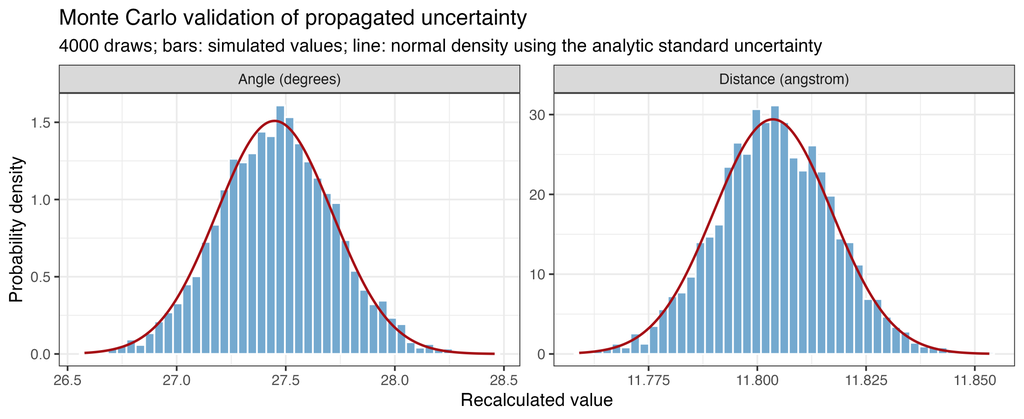

```r
knitr::include_graphics(file.path(validation_dir, "monte_carlo_validation.png"))
```

The observed relative differences are approximately 0.30% for distance and 0.40% for angle. These results support the first-order calculation for this non-collinear triclinic example and the stated input distributions. They do not recover unavailable refinement covariance or establish accuracy for every CIF, near-singular angle, or uncertainty magnitude.

## Publication Figure

```r
source("../scripts/export_publication_figures.R")
export_material_publication_figure(p, file.path(params$export_dir, "publication"))
```